# grounded-semantics

You will be using transfer learning on a large, known dataset called [MSCOCO](https://cocodataset.org/#download). Specifically, you will perform the task of "reference resolution" that identifies objects in images using referring expressions.

### Download dataset

The mscoco dataset is pretty big (12 GB). We won't be using all of the data, but it makes matters easier to have everything together in one place. To help you download the data, you can run the following script (might need to open the script and follow step by step on windows). You will only need to run this once!

%bash download_coco.sh

There is an https://github.com/lichengunc/refer/blob/master/refer.py to help you access and use the dataset. The main API is in the refer.py file. Run the following cell to import it, along with some other useful libraries (you may need to run pip to install them):

```python
from refer import REFER
import numpy as np
import skimage.io as io
import matplotlib.pyplot as plt
import os
from PIL import Image as PImage # pillow
```

### Load the MSOCO dataset with referring expressions, show some stats.

Notice that the datasets are already split into train, val, and test sets. This is to make it so everyone who uses the dataset can directly compare their results with each other.

You will train using the `train` set. You will develop your model with the `val` set. After you think you are done, you will perform a final evaluation on the `test` dataset.

```python
data_root = 'coco'  # contains refclef, refcoco, refcoco+, refcocog and images
dataset = 'refcoco'
splitBy = 'unc'
refer = REFER(data_root, dataset, splitBy)
```

```
loading dataset refcoco into memory...
creating index...
index created.
DONE (t=4.07s)
```

```python
# print stats about the given dataset
print ('dataset [%s_%s] contains: ' % (dataset, splitBy))
ref_ids = refer.getRefIds()
image_ids = refer.getImgIds()
print ('%s expressions for %s refs in %s images.' % (len(refer.Sents), len(ref_ids), len(image_ids)))

print ('\nAmong them:')
if dataset == 'refclef':
    if splitBy == 'unc':
        splits = ['train', 'val', 'testA', 'testB', 'testC']
    else:
        splits = ['train', 'val', 'test']
elif dataset == 'refcoco':
    splits = ['train', 'val', 'test']
elif dataset == 'refcoco+':
    splits = ['train', 'val', 'test']
elif dataset == 'refcocog':
    splits = ['train', 'val']  # we don't have test split for refcocog right now.

for split in splits:
    ref_ids = refer.getRefIds(split=split)
    print ('%s refs are in split [%s].' % (len(ref_ids), split))
```

```
dataset [refcoco_unc] contains:
142210 expressions for 50000 refs in 19994 images.

Among them:
42404 refs are in split [train].
3811 refs are in split [val].
3785 refs are in split [test].
```

### Example

- run the cells
- each sentence (i.e., referring expression) has an id with images and sub-images associated with it within a dictionary
- there is one object as a sub-image box denoted by the green box outline
- there are three referring expressions for that object

```python
ref_ids = refer.getRefIds()
print(len(ref_ids))
ref_id = 35254 # pick a random ref_id
ref = refer.Refs[ref_id]

ref # a dictionary with all of the needed info for a referring expression+image
```

```
50000
```

```
{'sent_ids': [100272, 100273, 100274],
 'file_name': 'COCO_train2014_000000173056_1.jpg',
 'ann_id': 275551,
 'ref_id': 35254,
 'image_id': 173056,
 'split': 'train',
 'sentences': [{'tokens': ['white', 'brown', 'sheep', 'right'],
   'raw': 'white brown sheep right',
   'sent_id': 100272,
   'sent': 'white brown sheep right'},
  {'tokens': ['black', 'sheep', 'on', 'right'],
   'raw': 'black sheep on right',
   'sent_id': 100273,
   'sent': 'black sheep on right'},
  {'tokens': ['sheep', 'on', 'the', 'right'],
   'raw': 'sheep on the right',
   'sent_id': 100274,
   'sent': 'sheep on the right'}],
 'category_id': 20}
```

```
ref_id [35254] (ann_id [275551])
1. white brown sheep right
2. black sheep on right
3. sheep on the right
```

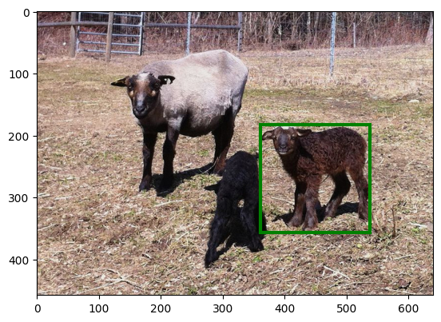

```python
print ('ref_id [%s] (ann_id [%s])' % (ref_id, refer.refToAnn[ref_id]['id']))
# show the segmentation of the referred object
plt.figure()
refer.showRef(ref, seg_box='box')
plt.show()
```

The following function extracts the sub-image (i.e., within a bounding box) from within the image.

```python
def get_bounded_subimage(img_id, ann_id, xs=224,ys=224, show=False):
    bbox = refer.Anns[ann_id]['bbox']
    bbox = [int(b) for b in bbox]
    img = refer.Imgs[img_id]
    I = io.imread(os.path.join(refer.IMAGE_DIR, img['file_name']))
    sub = I[bbox[1]:bbox[1]+bbox[3],bbox[0]:bbox[0]+bbox[2]]
    if show:
        plt.figure()
        ax = plt.gca()
        ax.imshow(sub)
        plt.show()
    if len(sub) == 0: return None
    pim = PImage.fromarray(sub)
    pim2 = pim.resize((xs,ys), PImage.LANCZOS)
    img = np.array(pim2)
    if len(img.shape) < 3: return None
    img = img.reshape((1, img.shape[0], img.shape[1], img.shape[2]))

    # Return pim for CLIP Format
    return pim
```

### Example sub-image / object

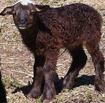

```python
get_bounded_subimage(ref['image_id'], ref['ann_id'], show=False)
```

The following function `compute_posfeats` is a useful function that extracts a handful of extra features, for example, the area that the subimage takes, the x,y coordinates, among other things. Using this function isn't required, but using it will yield better results.

```python
def compute_posfeats(img_id, ann_id,):
    img = refer.Imgs[img_id]
    bb = refer.Anns[ann_id]['bbox']
    fname = os.path.join(refer.IMAGE_DIR, img['file_name'])
    if not os.path.isfile(fname): return None
    img = io.imread(fname)

    if len(img.shape) < 3: return None
    ih, iw, _ = img.shape
    x,y,w,h = bb
    # x1, relative
    x1r = x / iw
    # y1, relative
    y1r = y / ih
    # x2, relative
    x2r = (x+w) / iw
    # y2, relative
    y2r = (y+h) / ih
    # area
    area = (w*h) / (iw*ih)
    # ratio image sides (= orientation)
    ratio = iw / ih
    # distance from center (normalised)
    cx = iw / 2
    cy = ih / 2
    bcx = x + w / 2
    bcy = y + h / 2
    distance = np.sqrt((bcx-cx)**2 + (bcy-cy)**2) / np.sqrt(cx**2+cy**2)
    # done!
    return np.array([x1r,y1r,x2r,y2r,area,ratio,distance]).reshape(1,7)
```

```python
# example using the sheep example on the compute_posfeats function
compute_posfeats(ref['image_id'], ref['ann_id']).flatten()
```

```
array([0.56284375, 0.39737991, 0.83945313, 0.77941048, 0.10567324,
       1.39737991, 0.34295148])
```

# Train

## Library Importing, Data Processing, Helper Functions

```python
from random import sample

# Split for compuation sake
train_ids = refer.getRefIds(split='train')
sample_train = sample(train_ids, int(len(train_ids) * .1))
len(sample_train)
```

```
4240
```

```python
import torch
import clip
from sklearn.linear_model import LogisticRegression
from torch.utils.data import DataLoader
import numpy as np
from nltk.corpus import stopwords
import tqdm as tqdm

stop_words = set(stopwords.words('english'))
```

```python
device = "mps" if torch.mps.is_available() else "cpu"
print(device)

clip_model, preprocess = clip.load('ViT-B/32', device)
```

```
mps
```

Get features for CLIP convnet

```python
def get_clip_features(image):
    try:
        # Preprocess image
        image = preprocess(image).unsqueeze(0).to(device)
        with torch.no_grad():
            features = clip_model.encode_image(image)
        return features.cpu().numpy().flatten()
    except Exception as e:
        print(f"Error processing {image}: {e}")
        return None
```

Extra all image features

```python
def get_img_features(bound_img, img_id, ann_id):
    # Get image features from CLIP model
    img_features = get_clip_features(bound_img)

    # Get extra features
    extra_features = compute_posfeats(img_id, ann_id).flatten()

    # Combines both features
    img_features = np.concatenate((img_features, extra_features))

    return img_features
```

Get unique words from sentence

```python
def get_unique_words(sentences):
    words_used = set()

    # Loop through each sentence of our image
    for sent in sentences:

        # Loops through each word of each sentence
        for word in sent['tokens']:

            # Loops through each word in sentence that isn't a stop word
            if word not in stop_words:
                words_used.add(word)
    return words_used
```

## Gather Positive Examples

```python
from sklearn.linear_model import LogisticRegression
import pickle
words_as_classifiers = {} # use something like this dictionary to store positive examples

# first, get all of the training data
train_ids = refer.getRefIds(split='train')

# Collecting Positive Examples for image classifer
for refer_id in tqdm.tqdm(train_ids):
    ref = refer.Refs[refer_id]
    img_id = ref['image_id']
    ann_id = ref['ann_id']

    # Get bounded sub image
    bound_img = get_bounded_subimage(img_id=img_id, ann_id=ann_id)

    # If bounded sub image DNE pass
    if bound_img != None:
        img_features = get_img_features(bound_img, ref['image_id'], ref['ann_id'])

        # Set of unique words. Used for managing duplicate words
        words_used = get_unique_words(ref['sentences'])

        # Looping through unique words
        for word in words_used:

            # Add new word to classifer
            if word not in words_as_classifiers:

                # Creates a dictonary for each word that has it's own classifer, positive, and negative examples
                words_as_classifiers[word] = {
                    "classifier" : LogisticRegression(C=.25, solver='newton-cg', max_iter=5000, n_jobs=-1, random_state=1738),
                    "positive": [], # Positive Examples of the word given the feature vectors
                    "negative": []  # Negative Examples of the word given the feature vectors
                }
            words_as_classifiers[word]["positive"].append(img_features)
```

## Gather Negative Examples

```python
# Collecting Negative Examples for image classifer
for refer_id in tqdm.tqdm(train_ids):
    ref = refer.Refs[refer_id]
    img_id = ref['image_id']
    ann_id = ref['ann_id']

    # Get bounded sub image
    bound_img = get_bounded_subimage(img_id=img_id, ann_id=ann_id)

    # If bounded sub image DNE pass
    if bound_img != None:

        img_features = get_img_features(bound_img, ref['image_id'], ref['ann_id'])

        # Making a set for reference words
        words_used = get_unique_words(ref['sentences'])

        # Loops through each word in classifer
        for word in words_as_classifiers:

            # If word is not in used words from current image we then at it too the negative vector set
            if word not in words_used:
                words_as_classifiers[word]['negative'].append(img_features)
```

## Training

```python
import pandas as pd

for word in tqdm.tqdm(words_as_classifiers):
    # Skip words with small amount of examples
    if len(words_as_classifiers[word]['positive']) < 5:
        continue

    # Making a data frame of positive and negative examples for each word, and putting a class with it
    pos_df = pd.DataFrame({'vectors': list(words_as_classifiers[word]['positive']), 'class': 1})
    neg_df = pd.DataFrame({'vectors': list(words_as_classifiers[word]['negative']), 'class' : 0})

    # Putting both dataframes together
    full_data_df = pd.concat([pos_df, neg_df], ignore_index=True).sample(frac=1, random_state=123).reset_index(drop=True)

    # Converting the data into a list for classifier
    X = list(full_data_df['vectors'])
    y = list(full_data_df['class'])

    # Fitting the classifier based on the positive and negative examples
    words_as_classifiers[word]['classifier'].fit(X,y)
```

```python
# Load the dictionary back
with open("train_features.pkl", "rb") as file:
    loaded_dict = pickle.load(file)
```

# Validate

```python
ref_id = eval_ids[0]
ref = refer.Refs[ref_id]
ann_id = ref['ann_id']  # this is the gold annotation id for all of the sentences
img_id = ref['image_id']
img = refer.Imgs[img_id]
objs = refer.imgToAnns[img_id] # objs is a list of all of the object annotations for the image, including the gold
```

```python
# step through the eval ids
import math
eval_ids = refer.getRefIds(split='val')
sample_eval = sample(eval_ids, int(len(eval_ids) * .1))

correct_pred = 0
false_pred = 0

for refer_id in tqdm.tqdm(eval_ids):
    ref = refer.Refs[refer_id]
    img_id = ref['image_id']
    ann_id = ref['ann_id']

    # Getting all objects in image
    objs = refer.imgToAnns[img_id]

    # Creating list of all of the object's in an image
    img_features = []
    object_ann_id = []

    # Looping through each object in the image
    # and grabbing the objects features
    for obj in objs:

        # Getting the ann_id for each object
        sub_ann_id = obj['id']

        obj_img = get_bounded_subimage(ref['image_id'], sub_ann_id, show=False)

        if obj_img == None:
            print('skipped')
            continue

        obj_features = get_img_features(bound_img=obj_img, ann_id=ref['ann_id'], img_id=ref['image_id'])

        # Adding image features to list
        img_features.append(obj_features)
        object_ann_id.append(sub_ann_id)

    # Making a set for reference words
    words_used = get_unique_words(sentences=ref['sentences'])

    # List of each objects score
    obj_score = []

    # Looping through each object's features
    # and getting it's probability that it matches the given phrase
    for img_feature in img_features:

        word_score = []

        # Looping throguh each word in classifier
        for word in words_as_classifiers:

            # Proceed if word is in current phrase
            #
            # Automatically skips any words not found in our word dictionary
            # by only getting words from our predefined list and seeing if its in
            # the current photo's annotation.
            if word in words_used:

                if len(words_as_classifiers[word]['positive']) < 5:
                    continue

                # Get probability that image matches this word
                # predict_proba returns [[p_negative, p_positive]]
                # [0][1] gets just the positive class probability (0=no match, 1=match)
                # Higher score means classifier is more confident the word applies to the image
                score = words_as_classifiers[word]['classifier'].predict_proba(img_feature.reshape(1,-1))[0][1]
                word_score.append(score)


        # Multiplies each words probability and adds it to the list for the current object
        obj_score.append(math.prod(word_score))

    # Creating a dataFrame for the score and it's annotation id
    score_df = pd.DataFrame({'id': object_ann_id, 'score': obj_score})

    try:
        # Getting the ann id based on the highest score
        max_score = max(score_df['score'])
        ann_id_picked = score_df[score_df['score'] == max_score]['id'].iloc[0]

        # Check if the model picked the right image
        if ann_id_picked == ann_id:
            correct_pred = correct_pred + 1
        else:
            false_pred = false_pred + 1

        # Checks every 200 image's the models accuracy
        if ((correct_pred + false_pred) % 200) == 0:
            print(correct_pred / (false_pred + correct_pred))

    except Exception as e:
        print('error')
        continue

model_acc = correct_pred / (false_pred + correct_pred)

print(f'Final Model Accuracy : {model_acc}')
print(f'Number of Correct    : {correct_pred}')
print(f'Number of Incorrect  : {false_pred}')
print(f'Total Predictions    : {correct_pred + false_pred}')
```

```
0.55
```

```
0.5325
```

```
0.5083333333333333
```

```
0.52625
```

```
0.52
```

```
skipped
```

```
skipped
```

```
0.505
```

[output not shown]

```
0.5
```

```
0.506875
```

```
0.5088888888888888
```

```
0.504
```

```
0.51
```

```
0.51125
```

```
0.5096153846153846
```

```
0.5157142857142857
```

```
0.5096666666666667
```

```
0.509375
```

```
0.5055882352941177
```

```
0.5038888888888889
```

```
0.5047368421052632
```

```
Final Model Accuracy : 0.5051194539249146
Number of Correct    : 1924
Number of Incorrect  : 1885
Total Predictions    : 3809
```

# Evaluate

- perform evaluation on the final test set **after** you're done developing and improving your model
- (you can run the cell below, then run the evaluation code you wrote as this overrides the `eval_ids` variable with the held out test set

```python
# step through the eval ids
import math
eval_ids = refer.getRefIds(split='test')
correct_pred = 0
false_pred = 0

for refer_id in tqdm.tqdm(eval_ids):
    ref = refer.Refs[refer_id]
    img_id = ref['image_id']
    ann_id = ref['ann_id']

    # Getting all objects in image
    objs = refer.imgToAnns[img_id]

    # Creating list of all of the object's in an image
    img_features = []
    object_ann_id = []

    # Looping through each object in the image
    # and grabbing the objects features
    for obj in objs:

        # Getting the ann_id for each object
        sub_ann_id = obj['id']

        obj_img = get_bounded_subimage(ref['image_id'], sub_ann_id, show=False)

        if obj_img == None:
            print('skipped')
            continue

        obj_features = get_img_features(bound_img=obj_img, ann_id=ref['ann_id'], img_id=ref['image_id'])

        # Adding image features to list
        img_features.append(obj_features)
        object_ann_id.append(sub_ann_id)

    # Making a set for reference words
    words_used = get_unique_words(sentences=ref['sentences'])

    # List of each objects score
    obj_score = []

    # Looping through each object's features
    # and getting it's probability that it matches the given phrase
    for img_feature in img_features:

        word_score = []

        # Looping throguh each word in classifier
        for word in words_as_classifiers:

            # Proceed if word is in current phrase
            #
            # Automatically skips any words not found in our word dictionary
            # by only getting words from our predefined list and seeing if its in
            # the current photo's annotation.
            if word in words_used:

                if len(words_as_classifiers[word]['positive']) < 5:
                    continue

                # Get probability that image matches this word
                # predict_proba returns [[p_negative, p_positive]]
                # [0][1] gets just the positive class probability (0=no match, 1=match)
                # Higher score means classifier is more confident the word applies to the image
                score = words_as_classifiers[word]['classifier'].predict_proba(img_feature.reshape(1,-1))[0][1]
                word_score.append(score)


        # Multiplies each words probability and adds it to the list for the current object
        obj_score.append(math.prod(word_score))

    # Creating a dataFrame for the score and it's annotation id
    score_df = pd.DataFrame({'id': object_ann_id, 'score': obj_score})

    try:
        # Getting the ann id based on the highest score
        max_score = max(score_df['score'])
        ann_id_picked = score_df[score_df['score'] == max_score]['id'].iloc[0]

        # Check if the model picked the right image
        if ann_id_picked == ann_id:
            correct_pred = correct_pred + 1
        else:
            false_pred = false_pred + 1

        # Checks every 200 image's the models accuracy
        if ((correct_pred + false_pred) % 200) == 0:
            print(correct_pred / (false_pred + correct_pred))

    except Exception as e:
        print('error')
        continue

model_acc = correct_pred / (false_pred + correct_pred)

print(f'Final Model Accuracy (Test Set) : {model_acc}')
print(f'Number of Correct    (Test Set) : {correct_pred}')
print(f'Number of Incorrect  (Test Set) : {false_pred}')
print(f'Total Predictions    (Test Set) : {correct_pred + false_pred}')
```

```
0.43
```

```
0.475
```

```
0.48
```

```
0.4825
```

```
0.479
```

```
0.4875
```

```
0.4828571428571429
```

[output not shown]

```
0.48875
```

```
0.49
```

```
0.487
```

```
0.4890909090909091
```

```
0.49
```

```
skipped
skipped
skipped
skipped
error
skipped
skipped
skipped
skipped
error
skipped
skipped
skipped
skipped
error
skipped
skipped
skipped
skipped
error
```

```
0.4973076923076923
```

```
0.4967857142857143
```

```
0.495
```

```
0.4953125
```

```
0.4938235294117647
```

```
0.4922222222222222
```

```
skipped
skipped
skipped
skipped
skipped
skipped
skipped
error
skipped
skipped
skipped
skipped
skipped
skipped
skipped
error
```

```
Final Model Accuracy (Test Set) : 0.49536669314270587
Number of Correct    (Test Set) : 1871
Number of Incorrect  (Test Set) : 1906
Total Predictions    (Test Set) : 3777
```

# Questions

- (answer the following below as a markdown cell)
- How well does your model perform on the test set (using the accuracy metric)?
- Is that a good score? How do you know?
- What assumptions does your model make? Hint: what would happen if the sentences/referring expressions had a different word order? Would it make a difference?
- What could you do to improve the model?

**How well does your model perform on the test set (using the accuracy metric)?**

The model preforms at ~50% accuracy, meaning the model was able to predict an object in an image fitting a given set of words 50% of the time. Given that a set of words could also match other object's in an image or other factors, this seems reasonable.

**Is that a good score? How do you know?**

```python
import random

correct_pred_index_1 = 0
false_pred_index_1 = 0
correct_pred = 0
false_pred = 0

# Testing using a random baseline where we randomly guess an annotation ID for each image.
for refer_id in tqdm.tqdm(eval_ids):
    ref = refer.Refs[refer_id]
    img_id = ref['image_id']
    ann_id = ref['ann_id']

    # Getting all objects in image
    objs = refer.imgToAnns[img_id]

    # Creating list of all of the object's in an image
    object_ann_id = []

    # Looping through each object in the image
    # and grabbing the objects features
    for obj in objs:

        # Getting the ann_id for each object
        sub_ann_id = obj['id']
        # Adding image features to list
        object_ann_id.append(sub_ann_id)

    ann_id_picked = random.choice(object_ann_id)
    ann_id_picked_index_1 = object_ann_id[0]

    # Check if the model picked the right image
    if ann_id_picked == ann_id:
        correct_pred = correct_pred + 1
    else:
        false_pred = false_pred + 1

    if ann_id_picked_index_1 == ann_id:
        correct_pred_index_1 = correct_pred_index_1 + 1
    else:
        false_pred_index_1 = false_pred_index_1 + 1

model_acc = correct_pred / (false_pred + correct_pred)
model_acc_index_1 = correct_pred_index_1 / (false_pred_index_1 + correct_pred_index_1)
print(f'Random Choice Accuracy : {model_acc}')
print(f'Index 1 Choice Accuracy : {model_acc_index_1}')
```

```
Random Choice Accuracy : 0.154557463672391
Index 1 Choice Accuracy : 0.18494055482166447
```

A score of 50% seems pretty good with the baselines we calculated. When picking some random choice from a list of `ann_id`'s, we get only 15% accuracy. When only picking the first index of the list of possible guesses, we get 18% accuracy. From this we can conclude that 50% accuracy is pretty good, as we were able to do better than just randomly picking an image.

**What assumptions does your model make?**

The model assumes independence between words in a phrase. This is because we take the probability of each word in a phrase matching a set of object features. We then multiply each word's probability by each other without accounting for dependency. For example, the phrase 'dark blue' makes dark have a dependency on blue, but we would treat them as independent anyway.

**What could you do to improve the model?**